# R Notebook

## Merging Data Frames

#### Daily Data

#### Weekly Data

#### Monthly Data

### EDA

```r
objects_to_keep <- c("df_merged_d", "df_merged_w", "df_merged_m")
# Remove all objects except those specified
rm(list = setdiff(ls(), objects_to_keep))
```

#### Daily Sales

#### Weekly sales

#### Monthly sales

#### Stacked bar plots

We want to move to a stacked bar chart when we care about the relative decomposition of each primary bar based on the levels of a second categorical variable. Each bar is now comprised of a number of sub-bars, each one corresponding with a level of a secondary categorical variable. The total length of each stacked bar is the same as before, but now we can see how the secondary groups contributed to that total.

One important consideration in building a stacked bar chart is to decide which of the two categorical variables will be the primary variable (dictating major axis positions and overall bar lengths) and which will be the secondary (dictating how each primary bar will be subdivided). The most ‘important’ variable should be the primary; use domain knowledge and the specific type of categorical variables to make a decision on how to assign your categorical variables

```r
#Monthly
# Reshape the data to a long format
df_sales_m_long <- df_merged_m %>%
  pivot_longer(cols = c(bar_m, food_m), names_to = "Category", values_to = "Value")

# Create the stacked bar plot
ggplot(df_sales_m_long, aes(x = month, y = Value, fill = Category)) +
  geom_bar(stat = "identity", position = "stack") +
  ggtitle("Monthly Sales of Restaurant") +
  labs(y = "Sales", x = "Month", fill = "Category") +
  theme_minimal()
```

[output not shown]

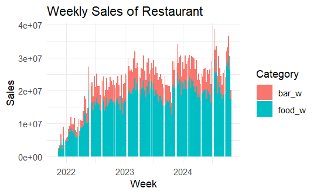

```r
df_sales_w_long <- df_merged_w %>%
  pivot_longer(cols = c(bar_w, food_w), names_to = "Category", values_to = "Value")

# Create the stacked bar plot
ggplot(df_sales_w_long, aes(x = week, y = Value, fill = Category)) +
  geom_bar(stat = "identity", position = "stack") +
  ggtitle("Weekly Sales of Restaurant") +
  labs(y = "Sales", x = "Week", fill = "Category") +
  theme_minimal()
```

#### Seasonal plots

```r
# Seasonal plots
df_sales_w_filtered <- df_merged_w %>%
  filter(week >= ymd("2021-12-31"))


tseries_w <- ts(df_sales_w_filtered$sales_w , start = c(2022, 1), frequency = 52)
head(tseries_w)
```

```
Time Series:
Start = c(2022, 1)
End = c(2022, 6)
Frequency = 52
[1]  5654618  5894371  8308052  9164178 11934123
[6]  9777570
```

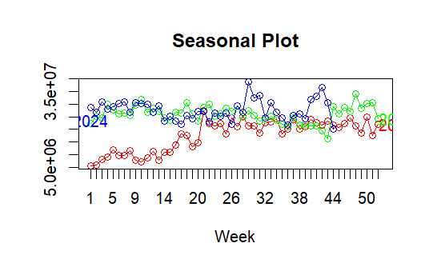

```r
seasonplot(tseries_w, col = rainbow(3), year.labels = TRUE, main = "Seasonal Plot")
text(x = 1, y = max(tseries_w) - 1.5e7, labels = "2024", col = "blue")
```

```r
NA
NA
```

```r
# seasonplot monthly
df_sales_m_filtered <- df_merged_m %>%
  filter(month >= ymd("2021-12-31"))


tseries_m <- ts(df_sales_m_filtered$sales_m , start = c(2022, 1), frequency = 12)
head(tseries_m)
```

```
          Jan      Feb      Mar      Apr
2022 31953282 41926179 37466677 57926246
          May      Jun
2022 79622843 88816435
```

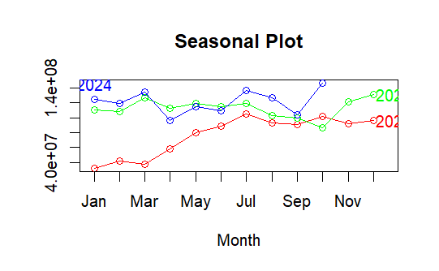

```r
seasonplot(tseries_m, col = rainbow(3), year.labels = TRUE, main = "Seasonal Plot")
text(x = 1, y = max(tseries_m) - 1e6, labels = "2024", col = "blue")
```

## Density

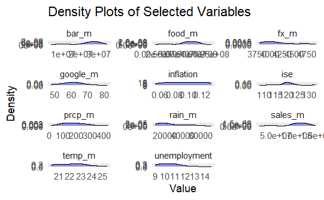

```r
# Montly Density
# Select the columns of interest
variables <- c("sales_m", "bar_m", "food_m", "rain_m", "fx_m", "google_m",
               "ise", "inflation", "unemployment", "temp_m", "prcp_m")


# Transform the data to long format for ggplot2
df_long_m <- df_merged_m %>%
  pivot_longer(cols = all_of(variables), names_to = "Variable", values_to = "Value")

# Create the grid of density plots
ggplot(df_long_m, aes(x = Value)) +
  geom_density(fill = "blue", alpha = 0.4) +
  facet_wrap(~ Variable, scales = "free", ncol = 3) +
  labs(title = "Density Plots of Selected Variables",
       x = "Value", y = "Density") +
  theme_minimal()
```

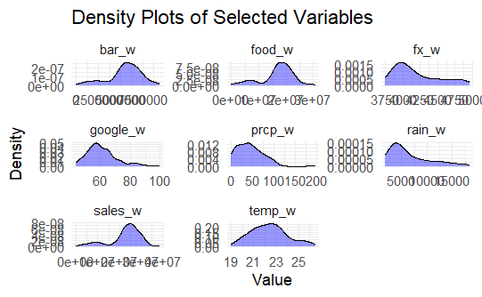

```r
# Weekly Density
# Select the columns of interest
variables <- c("sales_w", "bar_w", "food_w", "rain_w", "fx_w", "google_w",
                "temp_w", "prcp_w")



df_long_w <- df_merged_w %>%
  pivot_longer(cols = all_of(variables), names_to = "Variable", values_to = "Value")

# Create the grid of density plots
ggplot(df_long_w, aes(x = Value)) +
  geom_density(fill = "blue", alpha = 0.4) +
  facet_wrap(~ Variable, scales = "free", ncol = 3) +
  labs(title = "Density Plots of Selected Variables",
       x = "Value", y = "Density") +
  theme_minimal()
```

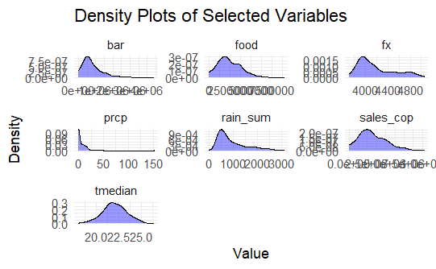

```r
# Daily Density

# Select the columns of interest
variables <- c("sales_cop", "bar", "food", "rain_sum", "fx",
               "tmedian", "prcp")



df_long_d <- df_merged_d %>%
  pivot_longer(cols = all_of(variables), names_to = "Variable", values_to = "Value")

# Create the grid of density plots
ggplot(df_long_d, aes(x = Value)) +
  geom_density(fill = "blue", alpha = 0.4) +
  facet_wrap(~ Variable, scales = "free", ncol = 3) +
  labs(title = "Density Plots of Selected Variables",
       x = "Value", y = "Density") +
  theme_minimal()
```

## Covariates

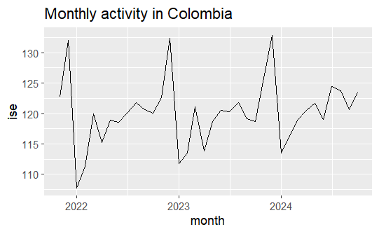

```r
### 3.5.1 economic variables-----------------------
# economic growth
ggplot(df_merged_m, aes(x=month, y=ise)) +
  geom_line() + ggtitle("Monthly activity in Colombia")
```

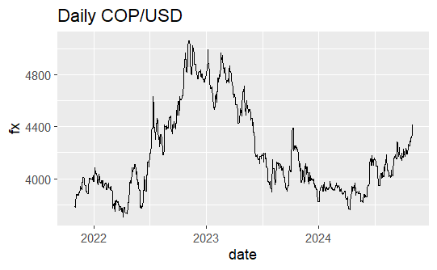

```r
# clearly seasonal and trend

# fx
ggplot(df_merged_d, aes(x=date, y=fx)) +
  geom_line() + ggtitle("Daily COP/USD")
```

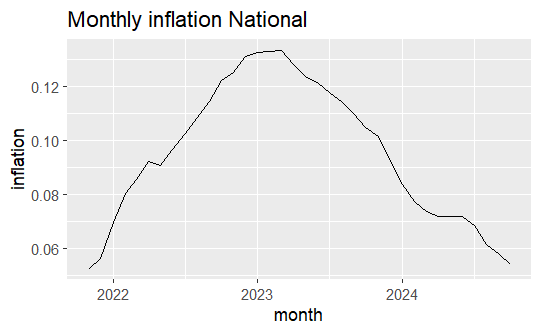

```r
# trend but no clear seasonality

# inflation
ggplot(df_merged_m, aes(x=month, y=inflation)) +
  geom_line() + ggtitle("Monthly inflation National")
```

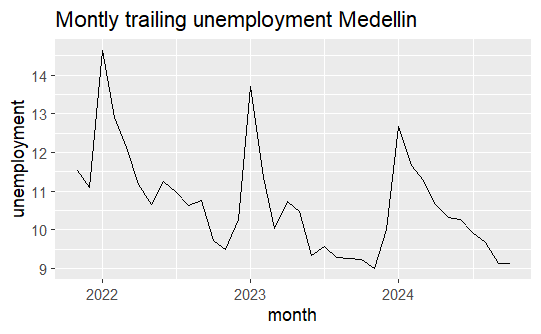

```r
# business cycles, no tend or seasonality

# unemployment
ggplot(df_merged_m, aes(x=month, y=unemployment)) +
  geom_line() + ggtitle("Montly trailing unemployment Medellin")
```

[figure not shown]

```r
# seasonal and trend downwards


### 3.5.2 Other variables

# google trends
ggplot(df_merged_w, aes(x=week, y=google_w)) +
  geom_line() + ggtitle("Weelkly Google trends 'Restaurantes'")
```

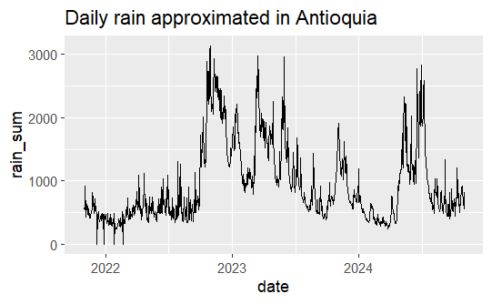

```r
# no clear behaviour, drop in pandemic

# rain
ggplot(df_merged_d, aes(x=date, y=rain_sum)) +
  geom_line() + ggtitle("Daily rain approximated in Antioquia")
```

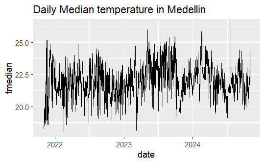

```r
# no trend or seasonality clearly

# temperature
ggplot(df_merged_d, aes(x=date, y=tmedian)) +
  geom_line() + ggtitle("Daily Median temperature in Medellin")
```

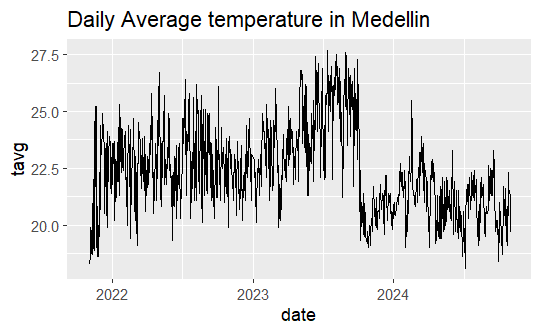

```r
# almost stationary

# temperature
ggplot(df_merged_d, aes(x=date, y=tavg)) +
  geom_line() + ggtitle("Daily Average temperature in Medellin")
```

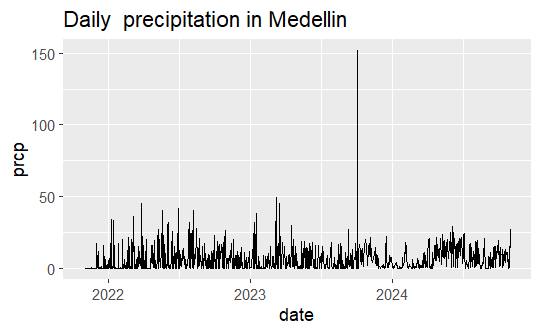

```r
# this one looks weird, better keep working on median

# precipitation from temp
ggplot(df_merged_d, aes(x=date, y=prcp)) +
  geom_line() + ggtitle("Daily  precipitation in Medellin")
```

```r
# looks decent
```

### Pairplots

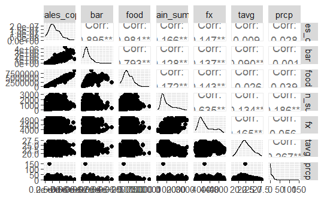

```r
df_merged_d <- subset(df_merged_d, select = -region)

# daily
ggpairs(df_merged_d,
        columns = 2:8)
```

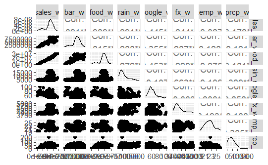

```r
# sales have correl with fx and rain_sum
# weekly
ggpairs(df_merged_w,
        columns = 2:9)
```

[figure not shown]

```r
# sales have correl with rain, google, fx, temp
# bar has more correl with temp

# montly
ggpairs(df_merged_m,
        columns = 2:12)
```

### Correlation Matrix

```r
# Exclude 'date' column
numeric_df_d <- df_merged_d[, sapply(df_merged_d, is.numeric)]
cor_matrix_d <- cor(numeric_df_d, use = "complete.obs")  # Use only complete rows
cor_matrix_d
```

```
            sales_cop          bar        food
sales_cop 1.000000000  0.895118281  0.98135791
bar       0.895118281  1.000000000  0.79301917
food      0.981357913  0.793019172  1.00000000
rain_sum  0.166252448  0.127567019  0.17164822
fx        0.146774104  0.136714885  0.14261504
tavg      0.008884659  0.089640797 -0.02562481
prcp      0.028085504 -0.001337552  0.03913167
tmedian   0.108891610  0.111686146  0.10120437
            rain_sum          fx         tavg
sales_cop  0.1662524  0.14677410  0.008884659
bar        0.1275670  0.13671488  0.089640797
food       0.1716482  0.14261504 -0.025624811
rain_sum   1.0000000  0.63500919 -0.134005147
fx         0.6350092  1.00000000  0.164550220
tavg      -0.1340051  0.16455022  1.000000000
prcp       0.1857676  0.05556529 -0.267367632
tmedian   -0.2717930 -0.07710937  0.656170981
                  prcp     tmedian
sales_cop  0.028085504  0.10889161
bar       -0.001337552  0.11168615
food       0.039131672  0.10120437
rain_sum   0.185767588 -0.27179302
fx         0.055565287 -0.07710937
tavg      -0.267367632  0.65617098
prcp       1.000000000 -0.22103872
tmedian   -0.221038724  1.00000000
```

```r
numeric_df_w <- df_merged_w[, sapply(df_merged_w, is.numeric)]
cor_matrix_w <- cor(numeric_df_w, use = "complete.obs")  # Use only complete rows
cor_matrix_w
```

```
             sales_w      bar_w      food_w
sales_w   1.00000000  0.8910033  0.98922211
bar_w     0.89100331  1.0000000  0.81506933
food_w    0.98922211  0.8150693  1.00000000
rain_w    0.29131607  0.2875652  0.27858415
google_w -0.44467552 -0.3551772 -0.45333238
fx_w      0.24395629  0.2873958  0.22038752
temp_w   -0.02746535  0.1275798 -0.07507291
prcp_w    0.17241188  0.1211778  0.18095801
             rain_w     google_w         fx_w
sales_w   0.2913161 -0.444675519  0.243956293
bar_w     0.2875652 -0.355177208  0.287395824
food_w    0.2785842 -0.453332380  0.220387520
rain_w    1.0000000 -0.107348280  0.662664730
google_w -0.1073483  1.000000000 -0.002777267
fx_w      0.6626647 -0.002777267  1.000000000
temp_w   -0.1062959  0.208497604  0.193152564
prcp_w    0.3289820 -0.251630474  0.107858510
              temp_w     prcp_w
sales_w  -0.02746535  0.1724119
bar_w     0.12757976  0.1211778
food_w   -0.07507291  0.1809580
rain_w   -0.10629590  0.3289820
google_w  0.20849760 -0.2516305
fx_w      0.19315256  0.1078585
temp_w    1.00000000 -0.3047876
prcp_w   -0.30478758  1.0000000
```

```r
numeric_df_m <- df_merged_m[, sapply(df_merged_m, is.numeric)]
cor_matrix_m <- cor(numeric_df_m, use = "complete.obs")  # Use only complete rows
cor_matrix_m
```

```
                 sales_m       bar_m     food_m
sales_m       1.00000000  0.91772972  0.9930535
bar_m         0.91772972  1.00000000  0.8646613
food_m        0.99305351  0.86466133  1.0000000
rain_m        0.34590142  0.35781875  0.3316856
fx_m          0.26008119  0.33043881  0.2325461
google_m     -0.60141163 -0.43583265 -0.6306910
ise           0.14184921  0.09197376  0.1528346
inflation     0.24620155  0.41865460  0.1885633
unemployment -0.47774546 -0.35355440 -0.4999277
temp_m       -0.05360312  0.12366320 -0.1041492
prcp_m        0.28057040  0.20114717  0.2956418
                   rain_m         fx_m
sales_m       0.345901419  0.260081195
bar_m         0.357818748  0.330438807
food_m        0.331685570  0.232546131
rain_m        1.000000000  0.700900212
fx_m          0.700900212  1.000000000
google_m     -0.127328581 -0.016302700
ise           0.143925313  0.006203153
inflation     0.554477494  0.731585721
unemployment -0.314673431 -0.148857922
temp_m       -0.004770513  0.242855832
prcp_m        0.364914544  0.106392263
                google_m          ise  inflation
sales_m      -0.60141163  0.141849210  0.2462015
bar_m        -0.43583265  0.091973761  0.4186546
food_m       -0.63069104  0.152834568  0.1885633
rain_m       -0.12732858  0.143925313  0.5544775
fx_m         -0.01630270  0.006203153  0.7315857
google_m      1.00000000  0.093304022  0.1600715
ise           0.09330402  1.000000000 -0.1118127
inflation     0.16007149 -0.111812691  1.0000000
unemployment  0.42550422 -0.602525241 -0.1308017
temp_m        0.33976804 -0.190530186  0.5982503
prcp_m       -0.37823361  0.047259121  0.0657641
             unemployment       temp_m
sales_m      -0.477745462 -0.053603118
bar_m        -0.353554400  0.123663200
food_m       -0.499927664 -0.104149167
rain_m       -0.314673431 -0.004770513
fx_m         -0.148857922  0.242855832
google_m      0.425504221  0.339768042
ise          -0.602525241 -0.190530186
inflation    -0.130801728  0.598250278
unemployment  1.000000000 -0.007286939
temp_m       -0.007286939  1.000000000
prcp_m       -0.415992203 -0.280144464
                  prcp_m
sales_m       0.28057040
bar_m         0.20114717
food_m        0.29564181
rain_m        0.36491454
fx_m          0.10639226
google_m     -0.37823361
ise           0.04725912
inflation     0.06576410
unemployment -0.41599220
temp_m       -0.28014446
prcp_m        1.00000000
```

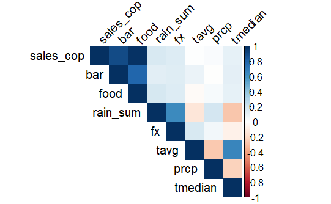

```r
# Plot the Correlation Matrix
par(mfrow=c(1,1))
corrplot(cor_matrix_d, method = "color", type = "upper", tl.col = "black", tl.srt = 45)
```

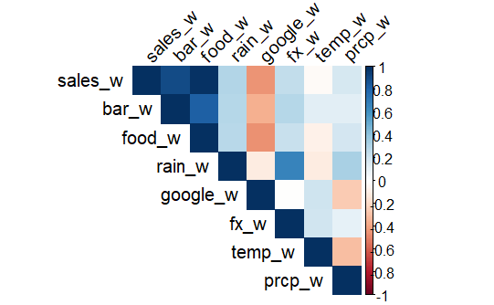

```r
corrplot(cor_matrix_w, method = "color", type = "upper", tl.col = "black", tl.srt = 45)
```

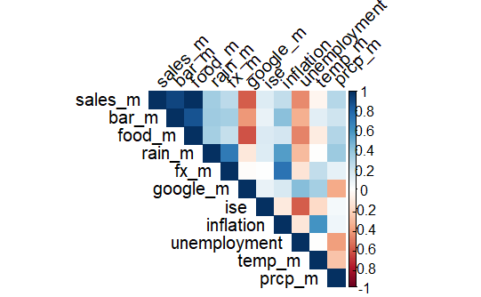

```r
corrplot(cor_matrix_m, method = "color", type = "upper", tl.col = "black", tl.srt = 45)
```

Rain has stronger correlation than prcp, so we drop prcp to not repeat the same variable from two sources Also we drop average temperature because median temperature seems more trustworthy

```r
# drop prcp beacuse they "are the same"
df_merged_m <- df_merged_m %>% select(-prcp_m)
df_merged_w <- df_merged_w %>% select(-prcp_w)
df_merged_d <- df_merged_d %>% select(-prcp)

# drop avg temp
df_merged_d <- df_merged_d %>% select(-tavg)
colnames(df_merged_d)
```

```
[1] "date"      "sales_cop" "bar"
[4] "food"      "rain_sum"  "fx"
[7] "tmedian"
```

```r
### drop everything not on use
objects_to_keep <- c("df_merged_d", "df_merged_w", "df_merged_m")
# Remove all objects except those specified
rm(list = setdiff(ls(), objects_to_keep))
```

### Variable Transformation

POSIXct and POSIXlt Classes

Times and date-times are represented by the POSIXct or the POSIXlt class in R. The POSIXct format stores date and time in seconds with the number of seconds beginning at January 1, 1970, so a POSIXct date-time is essentially an single value on a timeline. Date-times prior to 1970, will be negative numbers. The POSIXlt class stores other date and time information in a list such as hour of day of week, month of year, etc. The starting year for POSIXlt data is 1900, so 2022 would be stored as year 122. Months also begin at 0, so January is stored as month 0 and February as month 1. For both POSIX classes, the timezone can be classified. While date-times stored as POSIXct and POSIXlt look similar, when you unclass them with the unclass() function, you can see the additional information stored within the POSIXlt data.

Date Class

Dates without time can simply be stored as a Date class in R using the as.Date() function. Both Dates and POXIC classes need to be defined based on how they formatted. When uploading time series data into R, date and date-time data is typically uploaded as a character class and must be converted to date or time class using the as.Date(), as.POSIXct() or as.POSIXlt() functions.

Monthly

```r
# Vars for model
# Month
# Ensure the `month` column is in POSIXct format
df_merged_m$month <- as.POSIXct(df_merged_m$month)

# Create the numeric variable: an evenly increasing number
df_merged_m <- df_merged_m %>%
  arrange(month) %>%  # Ensure data is sorted by month
  mutate(numeric_month = row_number())  # Assign an increasing number

# Create the seasonal variable: the 12 different months as a factor
df_merged_m <- df_merged_m %>%
  mutate(seasonal_month = factor(format(month, "%B"), levels = month.name))  # Month names as ordered factors
```

Weekly

```r
# Week
# Ensure the `week` column is in POSIXct format
df_merged_w$week <- as.POSIXct(df_merged_w$week)

# Create the numeric variable: an evenly increasing number
df_merged_w <- df_merged_w %>%
  arrange(week) %>%  # Ensure data is sorted by week
  mutate(numeric_week = row_number())  # Assign an increasing number

# Create the seasonal variable: the 12 different months as a factor
df_merged_w <- df_merged_w %>%
  mutate(seasonal_month = factor(format(week, "%B"), levels = month.name))  # Month names as ordered factors
```

Daily

```r
# Day
# Ensure the `day` column is in POSIXct format
df_merged_d$date <- as.POSIXct(df_merged_d$date)

# Create the numeric variable: an evenly increasing number
df_merged_d <- df_merged_d %>%
  arrange(date) %>%  # Ensure data is sorted by day
  mutate(numeric_day = row_number())  # Assign an increasing number
```

```r
# Create the seasonal variable: the 12 different months as a factor
df_merged_d <- df_merged_d %>%
  mutate(seasonal_month = factor(format(date, "%B"), levels = month.name))  # Month names as ordered factors

# Create a column indicating the day of the week
df_merged_d <- df_merged_d %>%
  mutate(day_of_week = factor(weekdays(date), levels = c("Monday", "Tuesday", "Wednesday",
                                                         "Thursday", "Friday", "Saturday", "Sunday")))  # Day of the week as ordered factor
```

### Time Series Objects

Convert sales to time series objects for the use in several models

```r
# convert to time series
sales_d_ts <- ts(df_merged_d$sales_cop)
sales_w_ts <- ts(df_merged_w$sales_w)
sales_m_ts <- ts(df_merged_m$sales_m)

par(mfrow=c(1,1))

# Daily
tsdisplay(sales_d_ts)
```

[output not shown]

```r
# is not stationary but has no clear trend
# and seasonality every 7 days

# Weekly
tsdisplay(sales_w_ts)
```

[output not shown]

```r
# not stationary: has trend

# Montly
tsdisplay(sales_m_ts)
```

[output not shown]

```r
# has clear trend, no seasonality
```

### Log Transformation

Some variables are scaled to log, so we can interpret the linear models more easily. The covariates are in different scales so it is easier to interpret percentage changes instead of unit changes.

```r
# Monthly
df_merged_m <- df_merged_m %>%
  mutate(across(where(is.numeric) & !all_of(c("unemployment", "inflation")), ~ log(. + 1)))

# Weekly
df_merged_w <- df_merged_w %>%
  mutate(across(where(is.numeric), ~ log(. + 1)))

# Daily
# Weekly
df_merged_d <- df_merged_d %>%
  mutate(across(where(is.numeric), ~ log(. + 1)))
```

### Autocorrelation

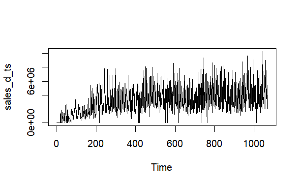

```r
#par(mfrow=c(1,1))
#tsdisplay(sales_d_ts)
# is not stationary but has no clear trend

plot(sales_d_ts)
```

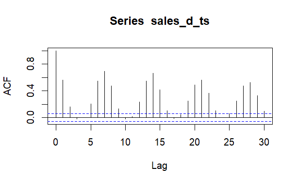

```r
acf(sales_d_ts)
```

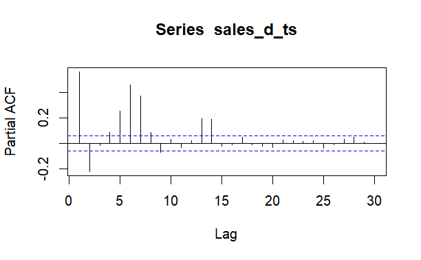

```r
pacf(sales_d_ts)
```

When data are seasonal, the autocorrelation will be larger for the seasonal lags (at multiples of the seasonal period) than for other lags.

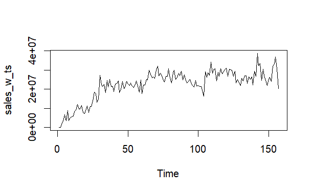

```r
# Weekly

#tsdisplay(sales_w_ts)
plot(sales_w_ts)
```

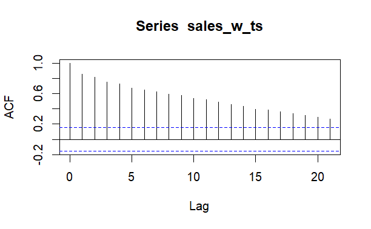

```r
acf(sales_w_ts)
```

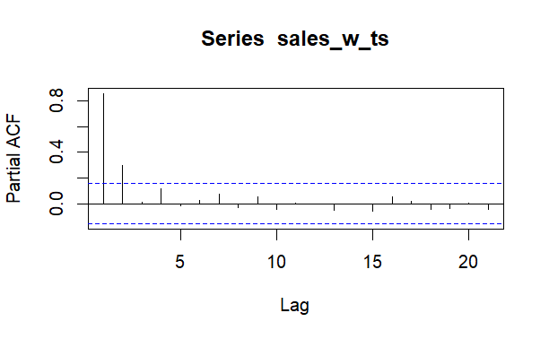

```r
pacf(sales_w_ts)
```

```r
# not stationary: has trend and seasonality maybe
```

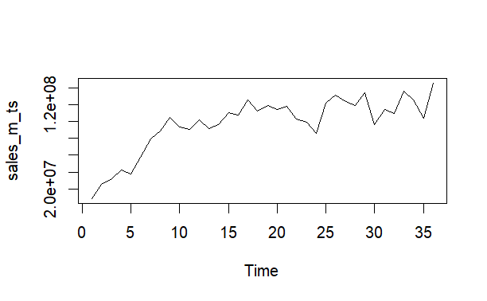

```r
# Montly

#tsdisplay(sales_m_ts)
plot(sales_m_ts)
```

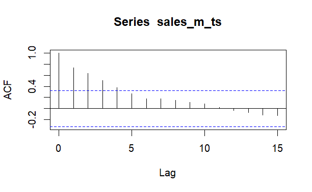

```r
acf(sales_m_ts)
```

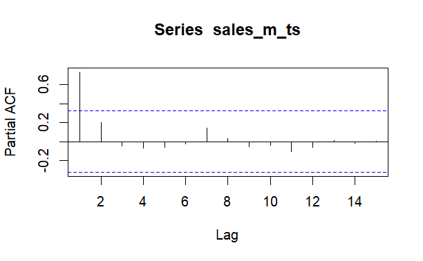

```r
pacf(sales_m_ts)
```

```r
# has clear trend, no seasonality
```

# Models

In this section we model the time series using various approaches to find the best model for our data. We use both linear and non linear models going from the simplest to the more “complex” models.

## Helper functions

Functions that help us implement and analyze models faster

```r
## Function to create and summarize models------------------
run_model <- function(formula, data, model_name) {
  cat("\nRunning", model_name, "\n")
  model <- lm(formula, data = data)
  print(summary(model))
  par(mfrow = c(2, 2))
  plot(model)
  return(model)
}

# Function to compare models using ANOVA
compare_models <- function(model1, model2, name1, name2) {
  cat("\nComparing Models:", name1, "vs", name2, "\n")
  anova_result <- anova(model1, model2)
  print(anova_result)
  return(anova_result)
}

# Function to add predictions to the dataset
add_predictions <- function(model, data, pred_column) {
  data[[pred_column]] <- predict(model, newdata = data)
  return(data)
}

# Calculate RMSE
# Function to calculate RMSE
calculate_rmse <- function(observed, predicted) {
  rmse <- sqrt(mean((observed - predicted)^2, na.rm = TRUE))
  return(rmse)
}


# function that compares linear models
# Define the function to get R^2 and AIC
get_model_stats <- function(models) {
  # Initialize an empty data frame
  stats <- data.frame(
    Model = character(),
    R2 = numeric(),
    AIC = numeric(),
    stringsAsFactors = FALSE
  )

  # Loop through the list of models
  for (i in seq_along(models)) {
    model <- models[[i]]
    model_name <- names(models)[i]
    # Extract R^2 and AIC
    r2 <- summary(model)$r.squared
    aic <- AIC(model)
    # Append to the data frame
    stats <- rbind(stats, data.frame(Model = model_name, R2 = r2, AIC = aic))
  }

  return(stats)
}
```

## Linear models

```r
# Montly Models
# View Dataframe
head(df_merged_m)
```

|  | month | sales_m | bar_m | food_m | rain_m | fx_m | google_m | ise | inflation | unemployment | temp_m | numeric_month | seasonal_month |
| --- | --- | --- | --- | --- | --- | --- | --- | --- | --- | --- | --- | --- | --- |
| 1 | 2021-11-01 | 15.88561 | 14.78705 | 15.48012 | 9.725349 | 8.269732 | 4.170534 | 4.818018 | 0.0526 | 11.5331 | 3.057924 | 0.6931472 | November |
| 2 | 2021-12-01 | 17.05863 | 15.85825 | 16.70041 | 9.462925 | 8.285043 | 4.418841 | 4.890889 | 0.0562 | 11.0965 | 3.180738 | 1.0986123 | December |
| 3 | 2022-01-01 | 17.27979 | 15.73987 | 17.03848 | 9.266820 | 8.294204 | 4.309456 | 4.689452 | 0.0694 | 14.6473 | 3.172393 | 1.3862944 | January |
| 4 | 2022-02-01 | 17.55142 | 16.24330 | 17.23626 | 9.154093 | 8.278133 | 4.139159 | 4.721480 | 0.0801 | 12.9052 | 3.160187 | 1.6094379 | February |
| 5 | 2022-03-01 | 17.43896 | 16.12177 | 17.12714 | 9.676637 | 8.244904 | 4.226834 | 4.794991 | 0.0853 | 12.1212 | 3.151909 | 1.7917595 | March |
| 6 | 2022-04-01 | 17.87468 | 16.48965 | 17.58658 | 9.862092 | 8.241171 | 4.320816 | 4.755253 | 0.0923 | 11.1685 | 3.171924 | 1.9459101 | April |

```
Running Model 0

Call:
lm(formula = formula, data = data)

Residuals:
    Min      1Q  Median      3Q     Max
-0.9910 -0.1192  0.0158  0.1476  0.4953

Coefficients:
              Estimate Std. Error t value Pr(>|t|)
(Intercept)   16.40311    0.18031   90.97  < 2e-16 ***
numeric_month  0.68309    0.06312   10.82 1.49e-12 ***
---
Signif. codes:
0 ‘***’ 0.001 ‘**’ 0.01 ‘*’ 0.05 ‘.’ 0.1 ‘ ’ 1

Residual standard error: 0.28 on 34 degrees of freedom
Multiple R-squared:  0.775, Adjusted R-squared:  0.7684
F-statistic: 117.1 on 1 and 34 DF,  p-value: 1.485e-12
```

[figure not shown]

```r
# Model 0: Trend only
ols0 <- run_model(sales_m ~ numeric_month, df_merged_m, "Model 0")
```

```
Running Model 1

Call:
lm(formula = formula, data = data)

Residuals:
    Min      1Q  Median      3Q     Max
-0.7403 -0.1590 -0.0135  0.2071  0.4347

Coefficients:
                         Estimate Std. Error t value
(Intercept)             16.505470   0.260998  63.240
numeric_month            0.657412   0.075865   8.666
seasonal_monthFebruary  -0.001699   0.254032  -0.007
seasonal_monthMarch     -0.006230   0.254345  -0.024
seasonal_monthApril     -0.063031   0.254777  -0.247
seasonal_monthMay        0.070611   0.255288   0.277
seasonal_monthJune       0.037438   0.255855   0.146
seasonal_monthJuly       0.138742   0.256462   0.541
seasonal_monthAugust    -0.010812   0.257098  -0.042
seasonal_monthSeptember -0.133330   0.257755  -0.517
seasonal_monthOctober   -0.058397   0.258427  -0.226
seasonal_monthNovember  -0.335279   0.254924  -1.315
seasonal_monthDecember  -0.016084   0.254094  -0.063
                        Pr(>|t|)
(Intercept)              < 2e-16 ***
numeric_month           1.06e-08 ***
seasonal_monthFebruary     0.995
seasonal_monthMarch        0.981
seasonal_monthApril        0.807
seasonal_monthMay          0.785
seasonal_monthJune         0.885
seasonal_monthJuly         0.594
seasonal_monthAugust       0.967
seasonal_monthSeptember    0.610
seasonal_monthOctober      0.823
seasonal_monthNovember     0.201
seasonal_monthDecember     0.950
---
Signif. codes:
0 ‘***’ 0.001 ‘**’ 0.01 ‘*’ 0.05 ‘.’ 0.1 ‘ ’ 1

Residual standard error: 0.311 on 23 degrees of freedom
Multiple R-squared:  0.8123,    Adjusted R-squared:  0.7144
F-statistic: 8.296 on 12 and 23 DF,  p-value: 8.937e-06
```

[figure not shown]

```r
df_merged_m <- add_predictions(ols0, df_merged_m, "predicted_sales0")

# Model 1: Trend + Seasonality
ols1 <- run_model(sales_m ~ numeric_month + seasonal_month, df_merged_m, "Model 1")
```

```r
df_merged_m <- add_predictions(ols1, df_merged_m, "predicted_sales1")


## Model 2: Backward Stepwise Regression

# Start with the full model (excluding food and bar)
ols2_full <- lm(
  sales_m ~ numeric_month + seasonal_month + unemployment + ise + fx_m +
    google_m + temp_m + rain_m,
  data = df_merged_m
)


# Perform backward stepwise regression
ols2_stepwise <- step(
  ols2_full,
  direction = "backward",
  trace = 1 # Prints the stepwise regression process
)
```

```
Start:  AIC=-104.31
sales_m ~ numeric_month + seasonal_month + unemployment + ise +
    fx_m + google_m + temp_m + rain_m

                 Df Sum of Sq     RSS      AIC
- temp_m          1   0.00008 0.69105 -106.310
- unemployment    1   0.01523 0.70620 -105.530
<none>                        0.69097 -104.314
- rain_m          1   0.07578 0.76674 -102.568
- seasonal_month 11   0.71692 1.40789 -100.691
- ise             1   0.17179 0.86276  -98.321
- fx_m            1   0.39083 1.08180  -90.176
- google_m        1   0.57575 1.26672  -84.495
- numeric_month   1   2.29957 2.99054  -53.570

Step:  AIC=-106.31
sales_m ~ numeric_month + seasonal_month + unemployment + ise +
    fx_m + google_m + rain_m

                 Df Sum of Sq     RSS      AIC
- unemployment    1   0.02314 0.71419 -107.125
<none>                        0.69105 -106.310
- rain_m          1   0.07693 0.76798 -104.510
- seasonal_month 11   0.79109 1.48214 -100.841
- ise             1   0.17775 0.86880 -100.070
- fx_m            1   0.43032 1.12137  -90.883
- google_m        1   0.65543 1.34648  -84.297
- numeric_month   1   2.42508 3.11613  -54.089

Step:  AIC=-107.12
sales_m ~ numeric_month + seasonal_month + ise + fx_m + google_m +
    rain_m

                 Df Sum of Sq    RSS      AIC
<none>                        0.7142 -107.125
- rain_m          1    0.0940 0.8082 -104.673
- seasonal_month 11    0.7847 1.4989 -102.437
- ise             1    0.1606 0.8748 -101.823
- fx_m            1    0.4343 1.1485  -92.022
- google_m        1    0.6466 1.3608  -85.916
- numeric_month   1    4.1118 4.8260  -40.342
```

```r
# Summary of the final stepwise model
summary(ols2_stepwise)
```

```
Call:
lm(formula = sales_m ~ numeric_month + seasonal_month + ise +
    fx_m + google_m + rain_m, data = df_merged_m)

Residuals:
     Min       1Q   Median       3Q      Max
-0.31229 -0.08760 -0.01030  0.09029  0.31789

Coefficients:
                         Estimate Std. Error t value
(Intercept)             -52.31160   19.99397  -2.616
numeric_month             0.93626    0.08952  10.459
seasonal_monthFebruary    0.27615    0.19812   1.394
seasonal_monthMarch      -0.33136    0.28825  -1.150
seasonal_monthApril      -0.03032    0.20910  -0.145
seasonal_monthMay        -0.12629    0.27633  -0.457
seasonal_monthJune       -0.16788    0.27401  -0.613
seasonal_monthJuly       -0.11655    0.30708  -0.380
seasonal_monthAugust     -0.45680    0.33544  -1.362
seasonal_monthSeptember  -0.40348    0.27930  -1.445
seasonal_monthOctober    -0.21625    0.28064  -0.771
seasonal_monthNovember   -0.67606    0.38426  -1.759
seasonal_monthDecember   -1.52898    0.67026  -2.281
ise                       7.20920    3.48786   2.067
fx_m                      2.72323    0.80115   3.399
google_m                  3.17853    0.76636   4.148
rain_m                   -0.20297    0.12835  -1.581
                        Pr(>|t|)
(Intercept)             0.016981 *
numeric_month           2.54e-09 ***
seasonal_monthFebruary  0.179459
seasonal_monthMarch     0.264583
seasonal_monthApril     0.886232
seasonal_monthMay       0.652850
seasonal_monthJune      0.547361
seasonal_monthJuly      0.708483
seasonal_monthAugust    0.189189
seasonal_monthSeptember 0.164861
seasonal_monthOctober   0.450439
seasonal_monthNovember  0.094603 .
seasonal_monthDecember  0.034247 *
ise                     0.052641 .
fx_m                    0.003010 **
google_m                0.000547 ***
rain_m                  0.130285
---
Signif. codes:
0 ‘***’ 0.001 ‘**’ 0.01 ‘*’ 0.05 ‘.’ 0.1 ‘ ’ 1

Residual standard error: 0.1939 on 19 degrees of freedom
Multiple R-squared:  0.9397,    Adjusted R-squared:  0.889
F-statistic: 18.52 on 16 and 19 DF,  p-value: 2.609e-08
```

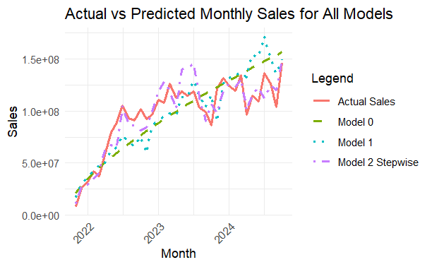

```r
# Add predictions from the final stepwise model
df_merged_m <- add_predictions(ols2_stepwise, df_merged_m, "predicted_sales2")

# Plot Actual vs Predicted Values
ggplot(df_merged_m, aes(x = month)) +
  geom_line(aes(y = exp(sales_m), color = "Actual Sales"), size = 1) +
  geom_line(aes(y = exp(predicted_sales0), color = "Model 0"), linetype = "dashed", size = 1) +
  geom_line(aes(y = exp(predicted_sales1), color = "Model 1"), linetype = "dotted", size = 1) +
  geom_line(aes(y = exp(predicted_sales2), color = "Model 2 Stepwise"), linetype = "dotdash", size = 1) +
  labs(title = "Actual vs Predicted Monthly Sales for All Models",
       x = "Month", y = "Sales", color = "Legend") +
  theme_minimal() +
  theme(axis.text.x = element_text(angle = 45, hjust = 1))
```

```r
# Models to compare
models <- list(
  "Model trend" = ols0,
  "Model trend + season" = ols1,
  "Model all covariates step" = ols2_stepwise
)

# Get R^2 and AIC for each model
model_stats <- get_model_stats(models)

# View the results
print(model_stats)
```

| Model | R2 | AIC |
| --- | --- | --- |
| Model trend | 0.7750083 | 14.461543 |
| Model trend + season | 0.8123201 | 29.933834 |
| Model all covariates step | 0.9397340 | -2.961086 |

```r
# Calculate RMSE for each model
rmse_stats <- data.frame(
  Model = character(),
  RMSE = numeric(),
  stringsAsFactors = FALSE
)

for (i in seq_along(models)) {
  model_name <- names(models)[i]
  predicted_column <- paste0("predicted_sales", i - 1) # Adjust index as per your data
  rmse <- calculate_rmse(df_merged_m$sales_m, df_merged_m[[predicted_column]])
  rmse_stats <- rbind(rmse_stats, data.frame(Model = model_name, RMSE = rmse))
}

# View RMSE statistics
print(rmse_stats)
```

| Model | RMSE |
| --- | --- |
| Model trend | 0.2721459 |
| Model trend + season | 0.2485578 |
| Model all covariates step | 0.1408493 |

```r
NA
```

```r
# Weekly Models
head(df_merged_w)
```

|  | week | sales_w | bar_w | food_w | rain_w | google_w | fx_w | temp_w | numeric_week | seasonal_month |
| --- | --- | --- | --- | --- | --- | --- | --- | --- | --- | --- |
| 1 | 2021-10-31 | 0.00000 | 0.00000 | 0.00000 | 8.361824 | 4.304065 | 8.246734 | 2.996446 | 0.6931472 | October |
| 2 | 2021-11-07 | 0.00000 | 0.00000 | 0.00000 | 8.256576 | 4.060443 | 8.263630 | 3.025984 | 1.0986123 | November |
| 3 | 2021-11-14 | 14.73012 | 13.66933 | 14.30519 | 8.060854 | 4.262680 | 8.270428 | 3.163061 | 1.3862944 | November |
| 4 | 2021-11-21 | 15.03593 | 13.81851 | 14.68496 | 8.437028 | 4.158883 | 8.281789 | 3.015535 | 1.6094379 | November |
| 5 | 2021-11-28 | 15.70331 | 14.75298 | 15.21455 | 8.275261 | 4.189655 | 8.289954 | 3.152125 | 1.7917595 | November |
| 6 | 2021-12-05 | 15.05661 | 14.01354 | 14.62217 | 7.803866 | 4.330733 | 8.274118 | 3.216015 | 1.9459101 | December |

```
Running Model 0A

Call:
lm(formula = formula, data = data)

Residuals:
     Min       1Q   Median       3Q      Max
-0.72559 -0.15917  0.01874  0.16674  0.65873

Coefficients:
             Estimate Std. Error t value Pr(>|t|)
(Intercept)  14.63582    0.10036  145.84   <2e-16 ***
numeric_week  0.53273    0.02372   22.46   <2e-16 ***
---
Signif. codes:
0 ‘***’ 0.001 ‘**’ 0.01 ‘*’ 0.05 ‘.’ 0.1 ‘ ’ 1

Residual standard error: 0.2406 on 153 degrees of freedom
Multiple R-squared:  0.7673,    Adjusted R-squared:  0.7658
F-statistic: 504.5 on 1 and 153 DF,  p-value: < 2.2e-16
```

[figure not shown]

```r
## Clean Data - Drop rows 1-2 because sales are 0 / was not open yet
df_merged_w <- df_merged_w %>% slice(-1, -2)

## Model 0A: Trend only
ols0w <- run_model(sales_w ~ numeric_week, df_merged_w, "Model 0A")
```

```
Running Model 1A

Call:
lm(formula = formula, data = data)

Residuals:
     Min       1Q   Median       3Q      Max
-0.62472 -0.14172  0.01215  0.16457  0.57707

Coefficients:
                        Estimate Std. Error t value
(Intercept)             14.67383    0.11499 127.613
numeric_week             0.53053    0.02537  20.915
seasonal_monthFebruary   0.01863    0.09432   0.197
seasonal_monthMarch     -0.07386    0.09266  -0.797
seasonal_monthApril     -0.04300    0.09278  -0.463
seasonal_monthMay        0.05120    0.09279   0.552
seasonal_monthJune       0.03179    0.09343   0.340
seasonal_monthJuly       0.09360    0.09164   1.021
seasonal_monthAugust    -0.03924    0.09572  -0.410
seasonal_monthSeptember -0.12111    0.09425  -1.285
seasonal_monthOctober   -0.08215    0.09245  -0.889
seasonal_monthNovember  -0.05447    0.09654  -0.564
seasonal_monthDecember  -0.13661    0.09221  -1.481
                        Pr(>|t|)
(Intercept)               <2e-16 ***
numeric_week              <2e-16 ***
seasonal_monthFebruary     0.844
seasonal_monthMarch        0.427
seasonal_monthApril        0.644
seasonal_monthMay          0.582
seasonal_monthJune         0.734
seasonal_monthJuly         0.309
seasonal_monthAugust       0.683
seasonal_monthSeptember    0.201
seasonal_monthOctober      0.376
seasonal_monthNovember     0.574
seasonal_monthDecember     0.141
---
Signif. codes:
0 ‘***’ 0.001 ‘**’ 0.01 ‘*’ 0.05 ‘.’ 0.1 ‘ ’ 1

Residual standard error: 0.2394 on 142 degrees of freedom
Multiple R-squared:  0.7862,    Adjusted R-squared:  0.7681
F-statistic:  43.5 on 12 and 142 DF,  p-value: < 2.2e-16
```

[figure not shown]

```r
df_merged_w <- add_predictions(ols0w, df_merged_w, "predicted_sales0")

## Model 1A: Trend + Seasonality
ols1w <- run_model(sales_w ~ numeric_week + seasonal_month, df_merged_w, "Model 1A")
```

```r
df_merged_w <- add_predictions(ols1w, df_merged_w, "predicted_sales1")


## Model 2A: Experimentation


# Start with the full model (excluding food and bar)
ols2_full_w <- lm(
  sales_w ~ numeric_week + seasonal_month + fx_w +
    google_w + temp_w + rain_w,
  data = df_merged_w
)


# Perform backward stepwise regression
ols2_stepwise_w <- step(
  ols2_full_w,
  direction = "backward",
  trace = 1 # Prints the stepwise regression process
)
```

```
Start:  AIC=-470.72
sales_w ~ numeric_week + seasonal_month + fx_w + google_w + temp_w +
    rain_w

                 Df Sum of Sq     RSS     AIC
- google_w        1    0.0047  5.9773 -472.59
- temp_w          1    0.0524  6.0250 -471.36
<none>                         5.9726 -470.72
- seasonal_month 11    0.9898  6.9624 -468.95
- rain_w          1    0.1643  6.1370 -468.51
- fx_w            1    1.1370  7.1096 -445.71
- numeric_week    1   16.1784 22.1510 -269.56

Step:  AIC=-472.59
sales_w ~ numeric_week + seasonal_month + fx_w + temp_w + rain_w

                 Df Sum of Sq     RSS     AIC
- temp_w          1    0.0597  6.0370 -473.05
<none>                         5.9773 -472.59
- seasonal_month 11    0.9855  6.9628 -470.94
- rain_w          1    0.1652  6.1426 -470.37
- fx_w            1    1.1490  7.1264 -447.34
- numeric_week    1   19.7232 25.7005 -248.52

Step:  AIC=-473.05
sales_w ~ numeric_week + seasonal_month + fx_w + rain_w

                 Df Sum of Sq     RSS     AIC
<none>                         6.0370 -473.05
- rain_w          1    0.2277  6.2648 -469.31
- seasonal_month 11    1.3008  7.3379 -464.81
- fx_w            1    1.6010  7.6380 -438.59
- numeric_week    1   20.3284 26.3655 -246.56
```

```r
# Summary of the final stepwise model
summary(ols2_stepwise_w)
```

```
Call:
lm(formula = sales_w ~ numeric_week + seasonal_month + fx_w +
    rain_w, data = df_merged_w)

Residuals:
    Min      1Q  Median      3Q     Max
-0.5797 -0.1243  0.0106  0.1247  0.5622

Coefficients:
                         Estimate Std. Error t value
(Intercept)             -1.941702   2.597439  -0.748
numeric_week             0.542540   0.024988  21.712
seasonal_monthFebruary   0.003119   0.082343   0.038
seasonal_monthMarch     -0.008609   0.081117  -0.106
seasonal_monthApril      0.058496   0.084093   0.696
seasonal_monthMay        0.160561   0.085157   1.885
seasonal_monthJune       0.171277   0.088309   1.940
seasonal_monthJuly       0.140843   0.079982   1.761
seasonal_monthAugust    -0.015579   0.083209  -0.187
seasonal_monthSeptember -0.130180   0.082537  -1.577
seasonal_monthOctober   -0.116443   0.081307  -1.432
seasonal_monthNovember  -0.011869   0.090153  -0.132
seasonal_monthDecember  -0.096493   0.081089  -1.190
fx_w                     2.106952   0.345784   6.093
rain_w                  -0.121385   0.052818  -2.298
                        Pr(>|t|)
(Intercept)               0.4560
numeric_week             < 2e-16 ***
seasonal_monthFebruary    0.9698
seasonal_monthMarch       0.9156
seasonal_monthApril       0.4878
seasonal_monthMay         0.0614 .
seasonal_monthJune        0.0544 .
seasonal_monthJuly        0.0804 .
seasonal_monthAugust      0.8518
seasonal_monthSeptember   0.1170
seasonal_monthOctober     0.1543
seasonal_monthNovember    0.8954
seasonal_monthDecember    0.2361
fx_w                    1.01e-08 ***
rain_w                    0.0230 *
---
Signif. codes:
0 ‘***’ 0.001 ‘**’ 0.01 ‘*’ 0.05 ‘.’ 0.1 ‘ ’ 1

Residual standard error: 0.2077 on 140 degrees of freedom
Multiple R-squared:  0.8414,    Adjusted R-squared:  0.8255
F-statistic: 53.04 on 14 and 140 DF,  p-value: < 2.2e-16
```